# Mini Project Team 2

### Analysis for Years in Current home

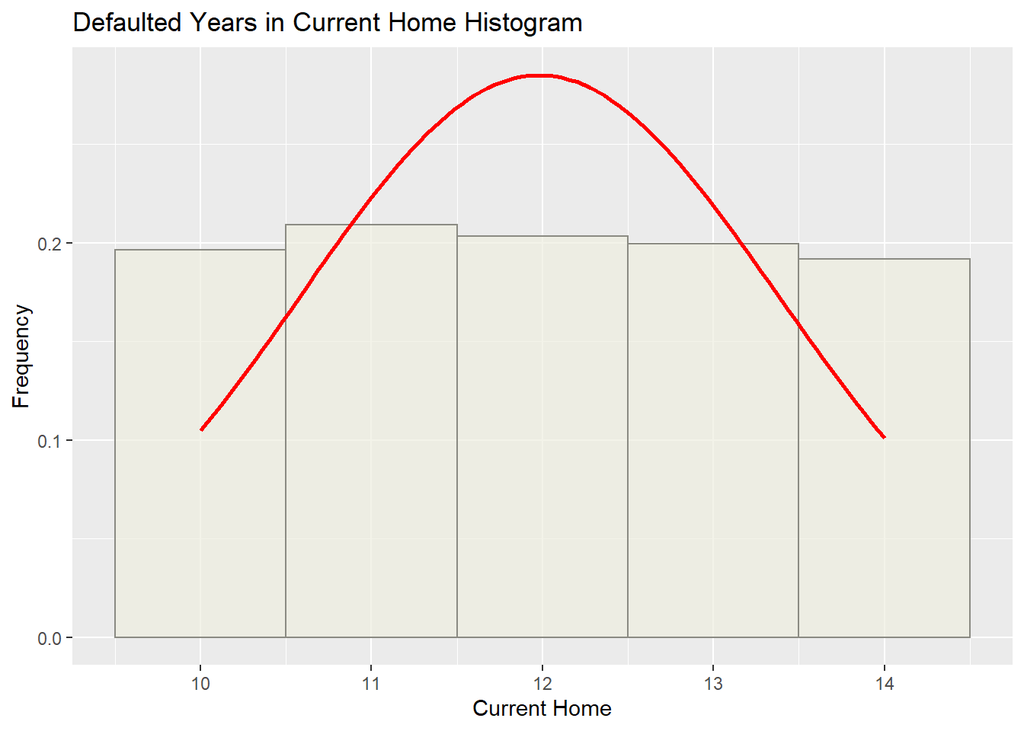

```r
ggplot(data=defaulted, aes(CURRENT_HOUSE_YRS)) +
  geom_histogram(aes(y=..density..),
                 binwidth = 1,
                 col="ivory4",
                 fill="ivory2",
                 alpha = .7) +
  stat_function(fun=dnorm, lwd = 1, col = 'red', args = list(mean = mean(defaulted$CURRENT_HOUSE_YRS, na.rm = TRUE), sd = sd(defaulted$CURRENT_HOUSE_YRS, na.rm = TRUE))) +
  labs(title="Defaulted Years in Current Home Histogram") +
  labs(x="Current Home", y="Frequency")
```

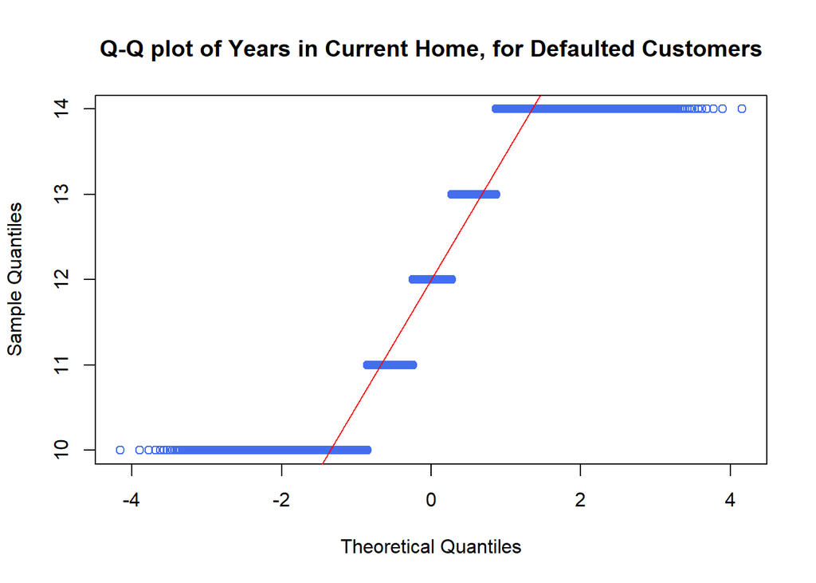

```r
qqnorm(defaulted$CURRENT_HOUSE_YRS, main="Q-Q plot of Years in Current Home, for Defaulted Customers", col = 'royalblue2')
qqline(defaulted$CURRENT_HOUSE_YRS, col = 'red')
```

As with our non-defaulted population, experience is uniformly distributed and has a discrete appearing QQ-plot. Again, we will leave this variable as a quantitative variable so that we can assess the impacts of 1 more year of experience impacting our variable.

### Analysis for Years in Current Job

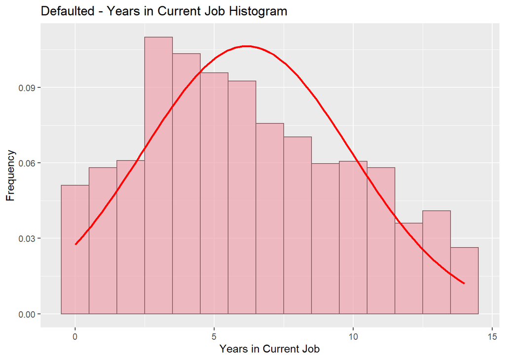

```r
ggplot(data=defaulted, aes(CURRENT_JOB_YRS)) +
  geom_histogram(aes(y=..density..),
                 binwidth = 1,
                 col="lightpink4",
                 fill="lightpink2",
                 alpha = .7) +
  stat_function(fun=dnorm, lwd = 1, col = 'red', args = list(mean = mean(defaulted$CURRENT_JOB_YRS, na.rm = TRUE), sd = sd(defaulted$CURRENT_JOB_YRS, na.rm = TRUE))) +
  labs(title="Defaulted - Years in Current Job Histogram") +
  labs(x="Years in Current Job", y="Frequency")
```

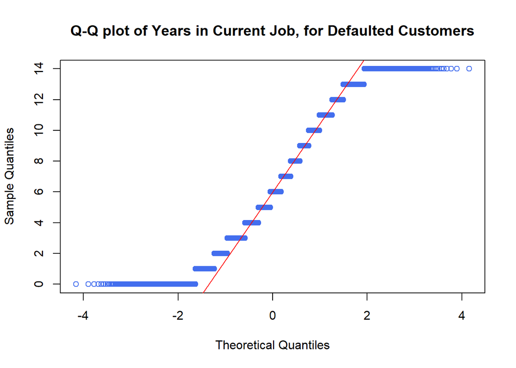

```r
qqnorm(defaulted$CURRENT_JOB_YRS, main="Q-Q plot of Years in Current Job, for Defaulted Customers", col = 'royalblue2')
qqline(defaulted$CURRENT_JOB_YRS, col = 'red')
```

Again, we see that years in current job appears to follow a relatively exponential distribution with a uniform left tail. This matches the non-defaulted sample distribution, so we can make inference on this mixed distribution. The QQ-plot further demonstrates this and, again, because we will make inference on the normally distributed sample mean (Central Limit Theorem), we will be able to conduct inferential statistics on our samples.

Now that we’ve confirmed the distributions of our two samples are within the same distribution families, we can go ahead and begin our statistical analyses to try and answer our posed questions.

### Qualitative Data Tests

First, lets deal with our qualitative data.

### Chi-Square Test

Let’s conduct our chi-square test for if home-ownership rates differ between those who default and those who don’t. Although a dependency may seem apparent, because our loans are not explicitly home loans, but rather consumer loans, which include car loans, home loans, wedding loans, student loans, etc. we will still analyze the dependency or independency of home-ownership and laon defaults. We set up our home_ownership hypotheses as follows:

$H_0$: Home Ownership Status and Loan Status are independent

$H_1$: Home Ownership Status and Loan Status are dependent

As per usual, we will use $\alpha$ = 0.05.

```r
#contigeny table
contable_housing = table(loandata$House_Ownership, loandata$Risk_Flag)
xkabledply(contable_housing, title = 'Contigency table for Risk Flag vs House Ownership ')
chitest_housing = chisq.test(contable_housing)

#To output results
chitest_housing
```

[output not shown]

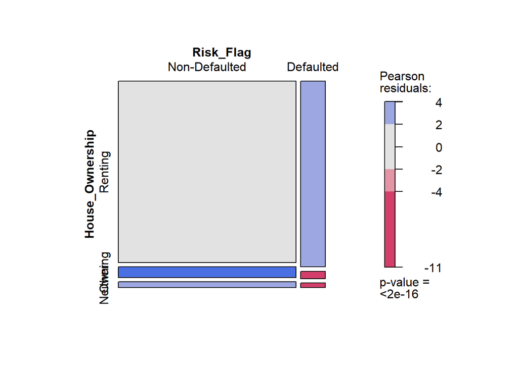

```r
library(lmtest)
library(grid)
library(vcd)

#Graphical representation of chi-square plot
mosaic(~ Risk_Flag + House_Ownership ,
  direction = c("v", "h"),
  data = loandata,
  shade = TRUE
)
```

This Chi-squared test shows that pvalue = 1.838^{-40} which means is statistically significant and indicates strong evidence against $H_0$ therefore we adopt $H_1$. After this test we reject our $H_0$ and accept $H_1$ Home Ownership Status and Loan Status are dependent. Knowing the value of one variables helps to predict the value of the other variable.

Next, we’ll assess if marital status has an impact on default status. We set up our marital status hypotheses as follows:

$H_0$: Marital Status and Loan Status are independent

$H_1$: Marital Status and Loan Status are dependent

As per usual, we will use $\alpha$ = 0.05.

```r
contable_marital = table(loandata$Married.Single, loandata$Risk_Flag)
xkabledply(contable_marital, title = 'Contigency table for Risk Flag vs Marital Status ')
chitest_marital = chisq.test(contable_marital)
chitest_marital
```

[output not shown]

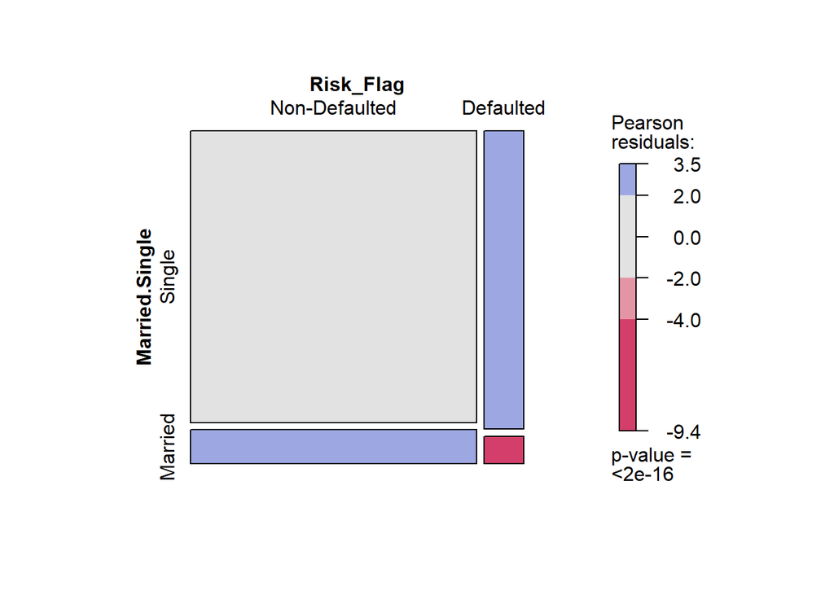

```r
#Produces graphical representation of chi-square
mosaic(~ Risk_Flag + Married.Single ,
  direction = c("v", "h"),
  data = loandata,
  shade = TRUE
)
```

## T-test

Now we’ll move back to our quantitative variables.

First, let’s analyze the income levels and if they differ significantly for defaulted vs. non-defaulted customers. Given that we are trying to assess if customers who have defaulted have lower incomes than those who haven’t, we would set up our hypothesis test as follows:

$H_0$: $\mu_{defaulted} \geq \mu_{not defaulted}$

$H_1$: $\mu_{defaulted} < \mu_{not defaulted}$

As per usual, we will use $\alpha$ = 0.05.

```r
ttest2sample_incomes = t.test(defaulted$Income, not_defaulted$Income, alternative = 'less')
#Output results
ttest2sample_incomes
```

[output not shown]

Here we fail to reject the Null Hypothesis $H_0$. We do not have enough evidence that the average income of defaulted vs. non-defaulted customers is different. We fail to reject th enull hypothesis with a p-value of 0.0627, which is greater than $\alpha$.

Now lets asses if years in current home is significantly different for those who have defaulted vs not defaulted. We set up our hypotheses for years in current home as follows:

$H_0$: $\mu_{defaulted} \geq \mu_{not defaulted}$

$H_1$: $\mu_{defaulted} < \mu_{not defaulted}$

As per usual, we will use $\alpha$ = 0.05.

```r
ttest2sample_currentHome = t.test(defaulted$CURRENT_HOUSE_YRS, not_defaulted$CURRENT_HOUSE_YRS, alternative = 'less')
#Output results
ttest2sample_currentHome
```

[output not shown]

With a p-value of 0.0141, which is less than $\alpha$, we can reject the Null Hypothesis $H_0$ in favor of the alternative hypothesis $H_1$. Therefore, at the $\alpha$ = 0.05 level, we can say that the average number of years in the current house for someone who has defaulted is significantly less than for someone who did not default.

Now we’ll examine overall job experience and if it differs between the two loan statuses. We set up our hypotheses for overall job experience as follows:

$H_0$: $\mu_{defaulted} = \mu_{not defaulted}$

$H_1$: $\mu_{defaulted} \neq \mu_{not defaulted}$

As per usual, we will use $\alpha$ = 0.05.

```r
ttest2sample_experience <- t.test(defaulted$Experience, not_defaulted$Experience, alternative = "two.sided")
#Output results
ttest2sample_experience
```

[output not shown]

Based on our t-test, we again reject the null hypothesis with a p-value of 8.91e-66 in favor of the alternative hypothesis $H_1$. Therefore, we can say that at an $\alpha$ = 0.05 level, the years of experience for someone who has defaulted differs significantly from the years of experience for someone who has not-defaulted.

We know overall job experience and years in current job are highly correlated, but it is still worth examining them separately even if we it is likely we’ll see the same result. Our hypotheses for years in current job are as follows:

$H_0$: $\mu_{defaulted} = \mu_{not defaulted}$

$H_1$: $\mu_{defaulted} \neq \mu_{not defaulted}$

As per usual, we will use $\alpha$ = 0.05.

```r
ttest2sample_currentjob <- t.test(defaulted$CURRENT_JOB_YRS, not_defaulted$CURRENT_JOB_YRS)
ttest2sample_currentjob
```

[output not shown]

Our test again shows our p-value of 1.02e-16 is less than our $\alpha$, so we can reject the null hypothesis in favor of the alternative hypothesis. Therefore, at the $\alpha$ = 0.05 level, we can say that years in current job differs significantly between those who have defaulted and those who haven’t.

Lastly, we’ll examine age and if customers who default on loans are significantly younger than those who do not. We’ll set up our age hypotheses as follows:

$H_0$: $\mu_{defaulted} \geq \mu_{not defaulted}$

$H_1$: $\mu_{defaulted} < \mu_{not defaulted}$

As per usual, we will use $\alpha$ = 0.05.

```r
ttest2sample_age <- t.test(defaulted$Age, not_defaulted$Age, alternative = 'less')
ttest2sample_age
```

[output not shown]

With our p-value of 2.27e-27, which is less than our $\alpha$=0.05, we can reject the null hypothesis in favor of the alternative. Therefore, the average age of those who have defaulted is statistically significantly lower than the average age of those who have not defaulted.

Now that we’ve completed our analyses, we can return to our initial questions to see what we’ve discovered. First, we discovered that we don’t have enough evidence to state that customers who defaulted have lower incomes than those who don’t. Second, we learned that rates of default is dependent with home-ownership status. Then we confirmed that marital status is also dependent with laon default status. Although we can’t confirm if an additional year of home-ownership reduces the likelihood of default, we can say that years of home-ownership differs significantly between those who have defaulted and those who haven’t. We also saw a similar result with overall job experience and years of experience in the current job. Finally, we saw that customers who have defaulted are in fact statistically significantly younger than those who have not.